Introduction: This is my Project 4 Explore and Summarize Data in Data Analyst Nanodegree Program. In this project, I explored the wine datasets and created univriate, bivariate and multivariate analysis respectively. In the last, I wrote up my reflection after finishing this project. Hope u enjoy it ; )

========================================================

# Univariate Plots Section

```
## Observations: 1,599
## Variables: 13
## $ X                    <int> 1, 2, 3, 4, 5, 6, 7, 8, 9, 10, 11, 12, 13...
## $ fixed.acidity        <dbl> 7.4, 7.8, 7.8, 11.2, 7.4, 7.4, 7.9, 7.3, ...
## $ volatile.acidity     <dbl> 0.700, 0.880, 0.760, 0.280, 0.700, 0.660,...
## $ citric.acid          <dbl> 0.00, 0.00, 0.04, 0.56, 0.00, 0.00, 0.06,...
## $ residual.sugar       <dbl> 1.9, 2.6, 2.3, 1.9, 1.9, 1.8, 1.6, 1.2, 2...
## $ chlorides            <dbl> 0.076, 0.098, 0.092, 0.075, 0.076, 0.075,...
## $ free.sulfur.dioxide  <dbl> 11, 25, 15, 17, 11, 13, 15, 15, 9, 17, 15...
## $ total.sulfur.dioxide <dbl> 34, 67, 54, 60, 34, 40, 59, 21, 18, 102, ...
## $ density              <dbl> 0.9978, 0.9968, 0.9970, 0.9980, 0.9978, 0...
## $ pH                   <dbl> 3.51, 3.20, 3.26, 3.16, 3.51, 3.51, 3.30,...
## $ sulphates            <dbl> 0.56, 0.68, 0.65, 0.58, 0.56, 0.56, 0.46,...
## $ alcohol              <dbl> 9.4, 9.8, 9.8, 9.8, 9.4, 9.4, 9.4, 10.0, ...
## $ quality              <int> 5, 5, 5, 6, 5, 5, 5, 7, 7, 5, 5, 5, 5, 5,...
```

```
##        X          fixed.acidity   volatile.acidity  citric.acid
##  Min.   :   1.0   Min.   : 4.60   Min.   :0.1200   Min.   :0.000
##  1st Qu.: 400.5   1st Qu.: 7.10   1st Qu.:0.3900   1st Qu.:0.090
##  Median : 800.0   Median : 7.90   Median :0.5200   Median :0.260
##  Mean   : 800.0   Mean   : 8.32   Mean   :0.5278   Mean   :0.271
##  3rd Qu.:1199.5   3rd Qu.: 9.20   3rd Qu.:0.6400   3rd Qu.:0.420
##  Max.   :1599.0   Max.   :15.90   Max.   :1.5800   Max.   :1.000
##  residual.sugar     chlorides       free.sulfur.dioxide
##  Min.   : 0.900   Min.   :0.01200   Min.   : 1.00
##  1st Qu.: 1.900   1st Qu.:0.07000   1st Qu.: 7.00
##  Median : 2.200   Median :0.07900   Median :14.00
##  Mean   : 2.539   Mean   :0.08747   Mean   :15.87
##  3rd Qu.: 2.600   3rd Qu.:0.09000   3rd Qu.:21.00
##  Max.   :15.500   Max.   :0.61100   Max.   :72.00
##  total.sulfur.dioxide    density             pH          sulphates
##  Min.   :  6.00       Min.   :0.9901   Min.   :2.740   Min.   :0.3300
##  1st Qu.: 22.00       1st Qu.:0.9956   1st Qu.:3.210   1st Qu.:0.5500
##  Median : 38.00       Median :0.9968   Median :3.310   Median :0.6200
##  Mean   : 46.47       Mean   :0.9967   Mean   :3.311   Mean   :0.6581
##  3rd Qu.: 62.00       3rd Qu.:0.9978   3rd Qu.:3.400   3rd Qu.:0.7300
##  Max.   :289.00       Max.   :1.0037   Max.   :4.010   Max.   :2.0000
##     alcohol         quality
##  Min.   : 8.40   Min.   :3.000
##  1st Qu.: 9.50   1st Qu.:5.000
##  Median :10.20   Median :6.000
##  Mean   :10.42   Mean   :5.636
##  3rd Qu.:11.10   3rd Qu.:6.000
##  Max.   :14.90   Max.   :8.000
```

OUr dataset consists of 12 variables (X1 is the order number, so I will ignore that), with almost 1,599 observations.

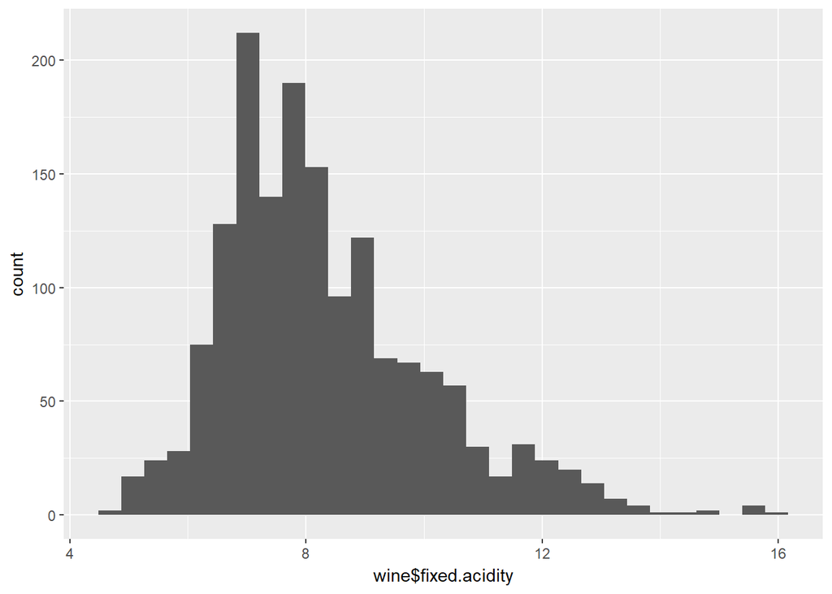

Description: This is wine$fixed.acidity histogram. From this plot, we can observe that it`s generally normal distribution.

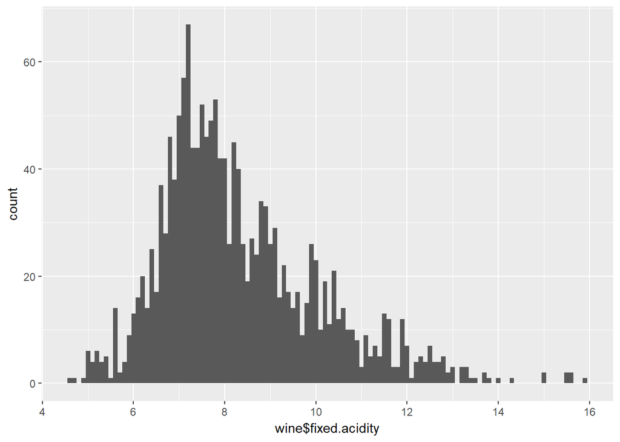

Description: This is a detailed plot of the plot above which I added scale_x_continuous breaks to dive into the plot. I got to know that most of wine`s fixed acidity is about 7.

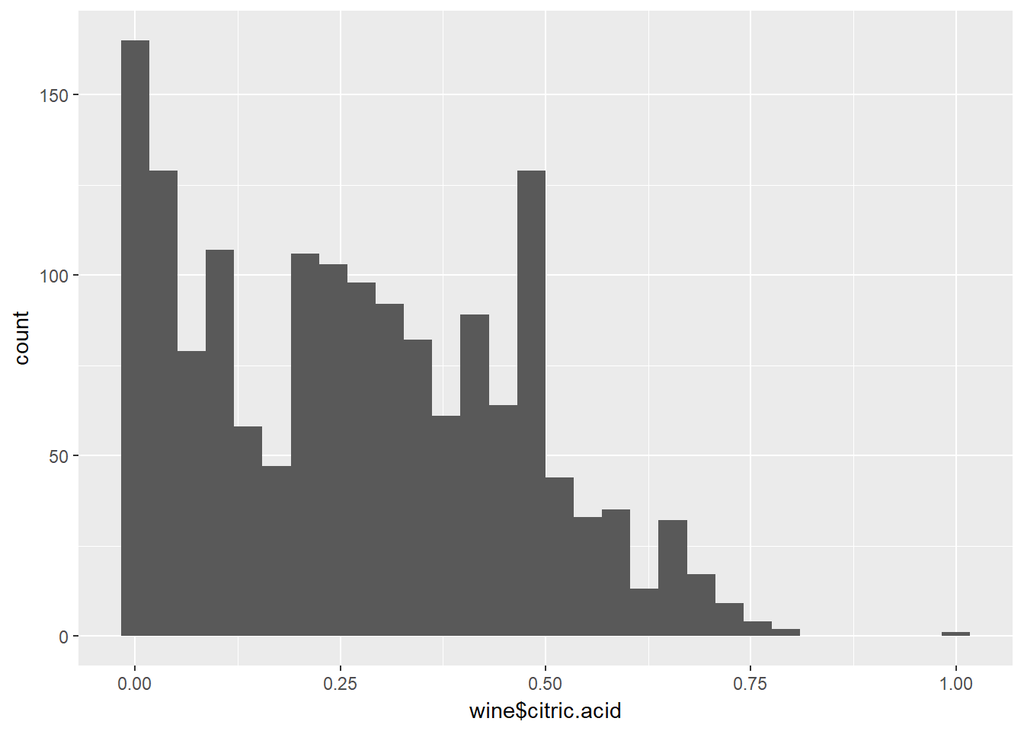

Description: This is a wine$citric.acid histogram. I checked the information textfile “3 - citric acid: found in small quantities, citric acid can add ‘freshness’ and flavor to wines” which is consistent with the plot (small quantities).

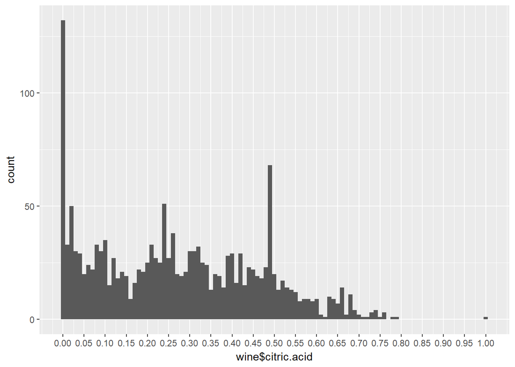

```
##    Min. 1st Qu.  Median    Mean 3rd Qu.    Max.
##   0.000   0.090   0.260   0.271   0.420   1.000
```

```
##
##    0 0.01 0.02 0.03 0.04 0.05 0.06 0.07 0.08 0.09  0.1 0.11 0.12 0.13 0.14
##  132   33   50   30   29   20   24   22   33   30   35   15   27   18   21
## 0.15 0.16 0.17 0.18 0.19  0.2 0.21 0.22 0.23 0.24 0.25 0.26 0.27 0.28 0.29
##   19    9   16   22   21   25   33   27   25   51   27   38   20   19   21
##  0.3 0.31 0.32 0.33 0.34 0.35 0.36 0.37 0.38 0.39  0.4 0.41 0.42 0.43 0.44
##   30   30   32   25   24   13   20   19   14   28   29   16   29   15   23
## 0.45 0.46 0.47 0.48 0.49  0.5 0.51 0.52 0.53 0.54 0.55 0.56 0.57 0.58 0.59
##   22   19   18   23   68   20   13   17   14   13   12    8    9    9    8
##  0.6 0.61 0.62 0.63 0.64 0.65 0.66 0.67 0.68 0.69  0.7 0.71 0.72 0.73 0.74
##    9    2    1   10    9    7   14    2   11    4    2    1    1    3    4
## 0.75 0.76 0.78 0.79    1
##    1    3    1    1    1
```

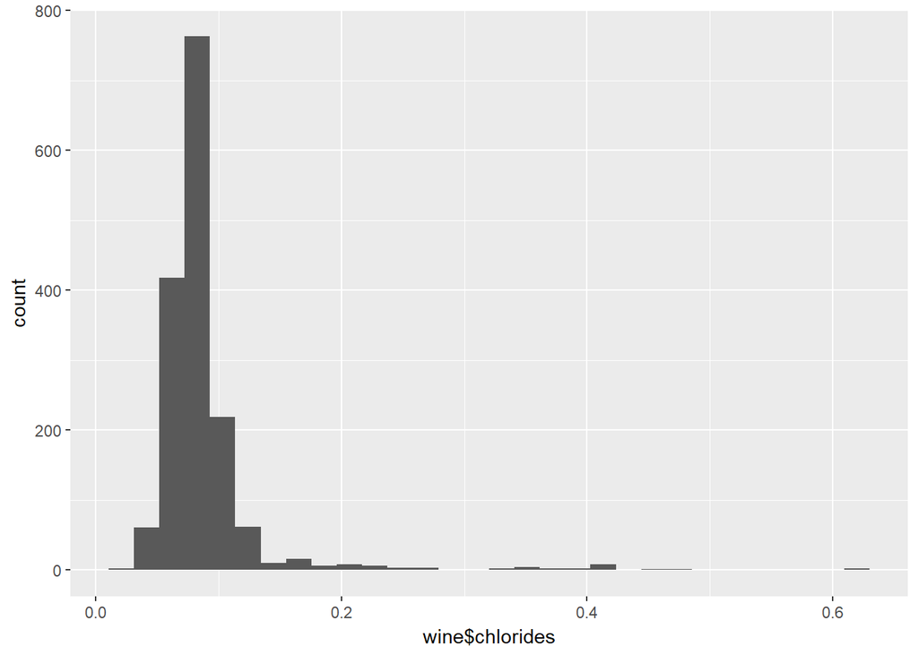

Description: An histogram about wine chlorides. As you can see, wine$chlorides plot concentrates on the range of 0.05-0.15.

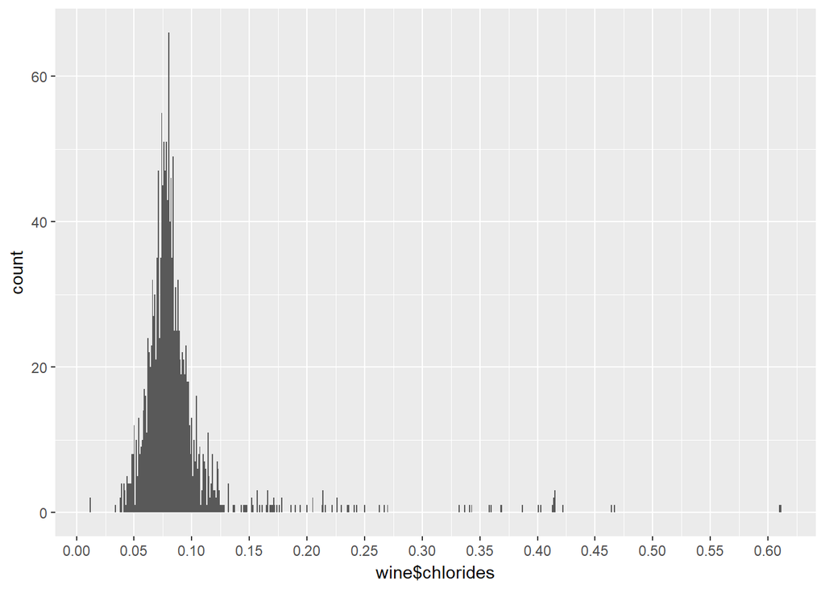

Description: In order to observe the plot closely, I added detailed breaks on x-axis. In addition, this is an perfect normal distribution in my view despite of some outliers.

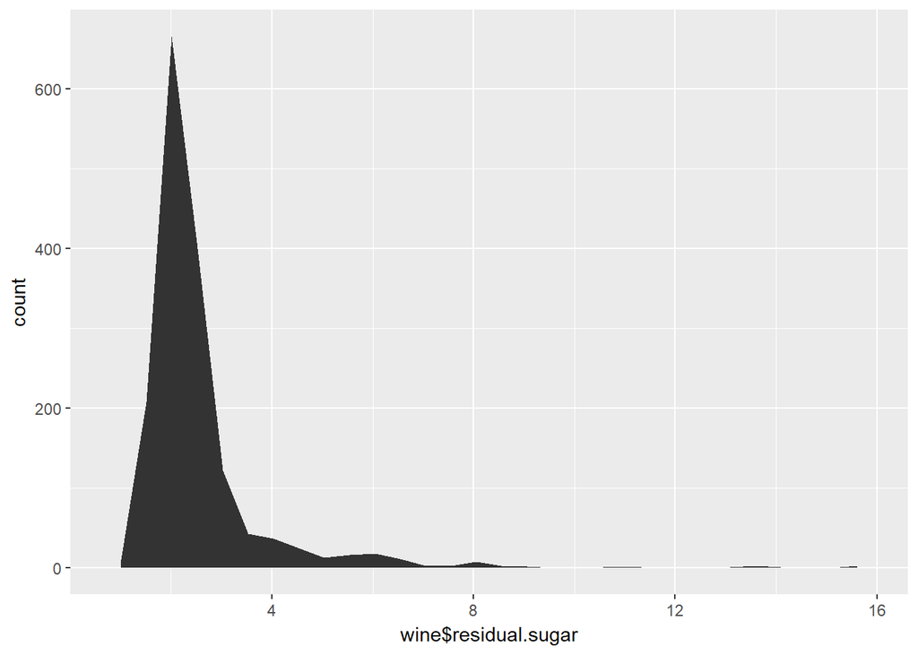

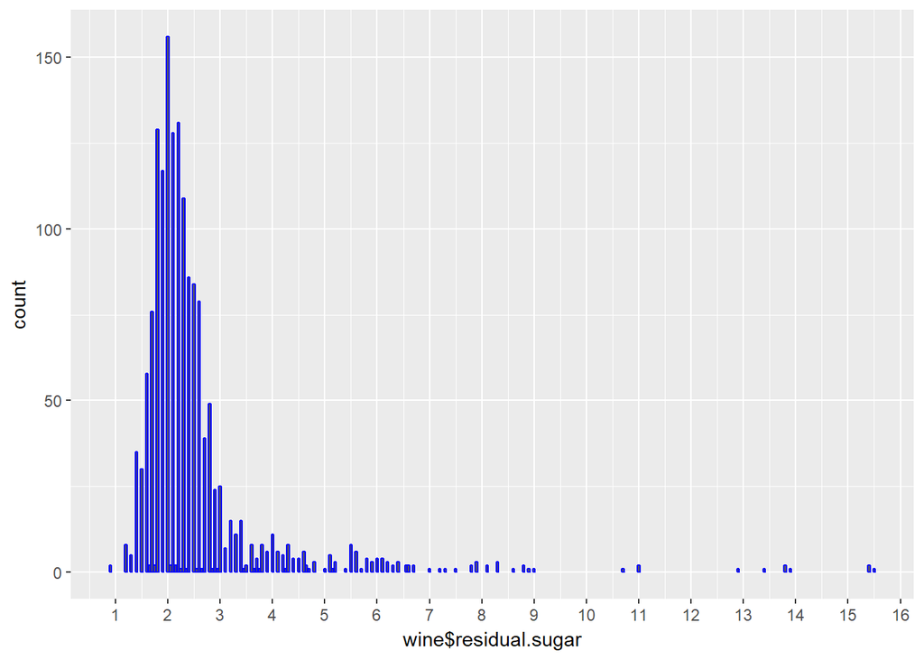

Description: An histogram of wine residual sugar. Most of wine residual sugar concentrate on the range of 1.5 - 3.0.

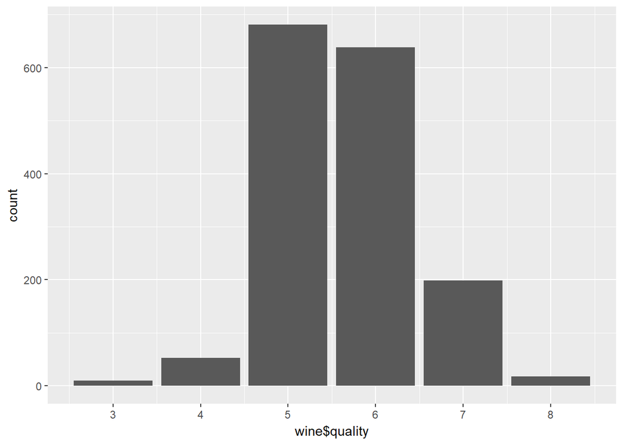

Description: A histogram of wine quality. It seems that most of wine`s qualtity is medium-level(5-6).

```
##
##   3   4   5   6   7   8
##  10  53 681 638 199  18
```

Description: Obviously, most of wine`s quality is fair not good (5-6). Later, I wanna get insight into what aspects affect the quality most. For buyers, we can differentiate wine quality with some basic ideas or preconceived criterion. For producers, they can pay attention to these factors which play an important role in wine quality. By doing so, wine producers can produce better quality wine to customers. More significantly, they could increase their sales and make profits ;)

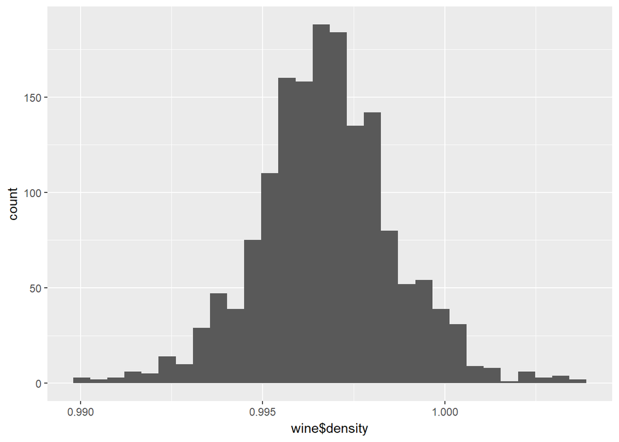

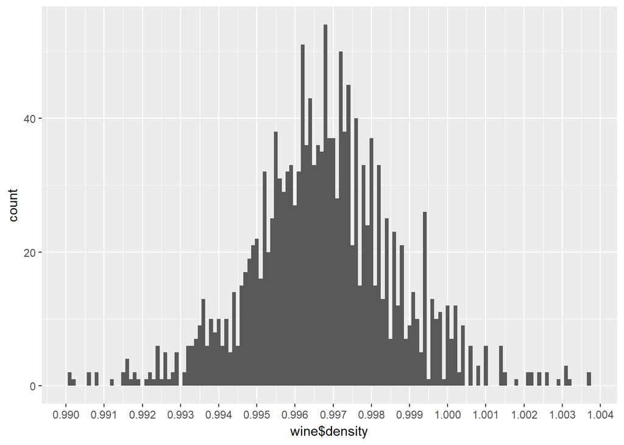

```
##    Min. 1st Qu.  Median    Mean 3rd Qu.    Max.
##  0.9901  0.9956  0.9968  0.9967  0.9978  1.0037
```

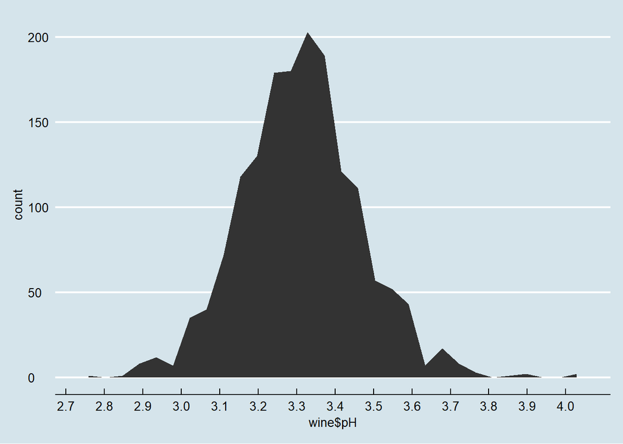

Description: An area plot of Wine PH which represents a normal distribution and indicates that the majority of wine Ph is the range of 3.2 ~ 3.5.

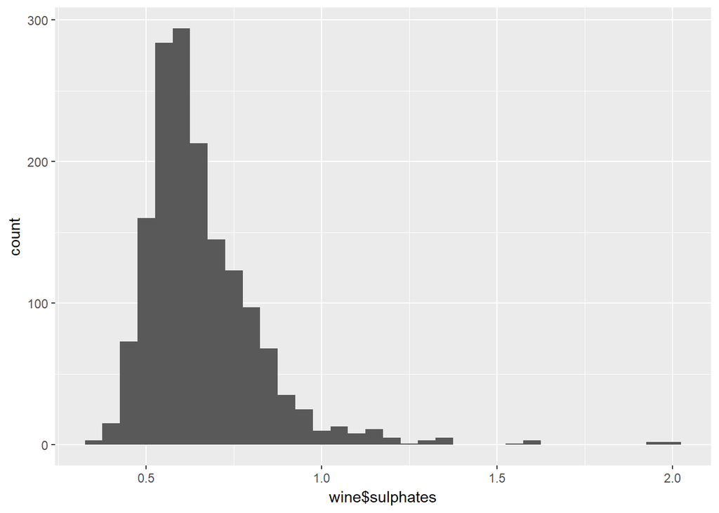

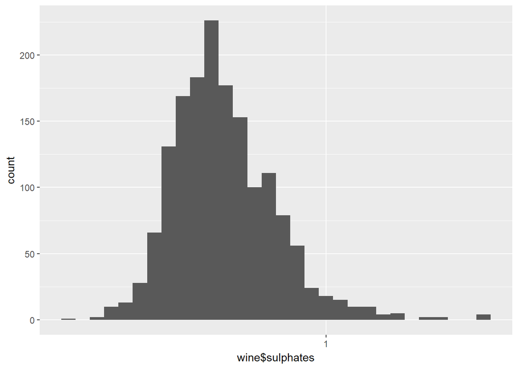

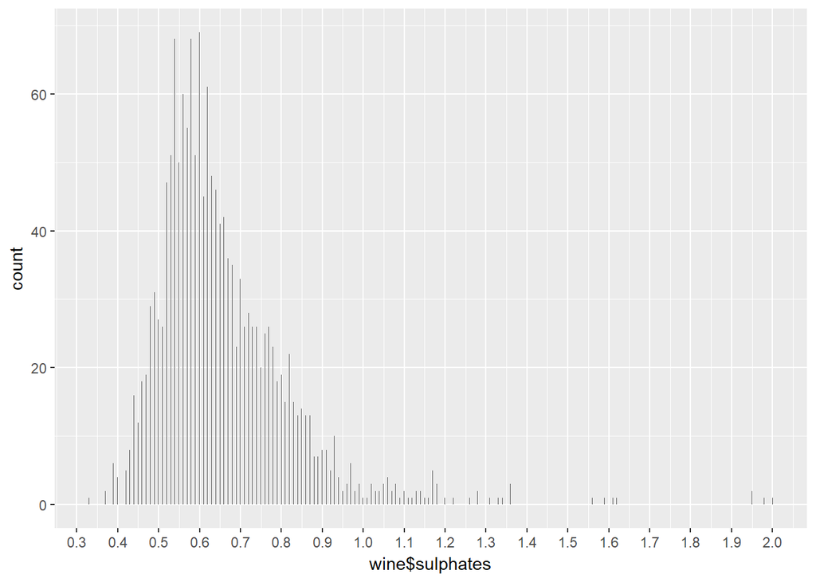

Description: There is one noticing break between 0.5 and 1.0 range. I wonder why there is a break in this plot. I guess maybe that`s part of reason that the sample is not large enough

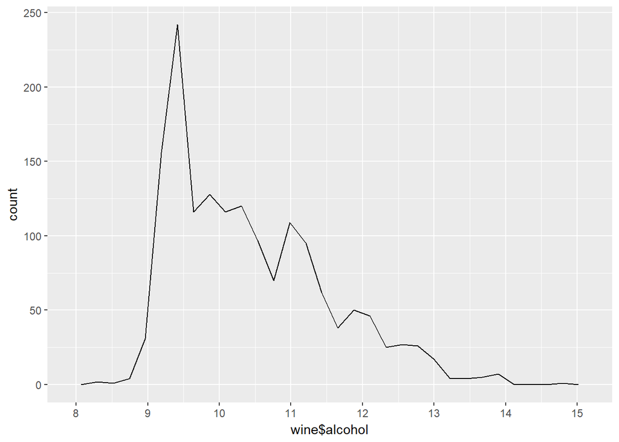

# Univariate Analysis

### What is the structure of your dataset?

There are 1,599 wines in the dataset with 12 features (Input variables (based on physicochemical tests): 1 - fixed acidity (tartaric acid - g / dm^3) 2 - volatile acidity (acetic acid - g / dm^3) 3 - citric acid (g / dm^3) 4 - residual sugar (g / dm^3) 5 - chlorides (sodium chloride - g / dm^3) 6 - free sulfur dioxide (mg / dm^3) 7 - total sulfur dioxide (mg / dm^3) 8 - density (g / cm^3) 9 - pH 10 - sulphates (potassium sulphate - g / dm3) 11 - alcohol (% by volume) Output variable (based on sensory data): 12 - quality (score between 0 and 10)).

The variable quality is an ordered factor variables with the following level:

(worst -> best) 0,1,2,3,4,5,6,8,9,10

### What is/are the main feature(s) of interest in your dataset?

The main feature in the the data set are volatile acidity, citric acid and alcohol. I`d like to determine which features play a more sinificant role in wine quality. I suspect that citric acid may play an important effect in wine quality before I get started.

### What other features in the dataset do you think will help support your investigation into your feature(s) of interest?

Admittedly, fixed acidity, chlorides, density suplates are likely to contribute to the quality of wine. Because the plot is similar to the quality plot. I think, however, citric acid(found in small quantities) and alcohol probably contribute most to the quality. I can`t help starting exploration. But I know I should think twice before I do.

### Did you create any new variables from existing variables in the dataset?

I didn`t create new variable right now and I would do that later according to my exploration requirement.

### Of the features you investigated, were there any unusual distributions? Did you perform any operations on the data to tidy, adjust, or change the form of the data? If so, why did you do this?

Yeap, the plot of wine$sulphates is a little unsual because there is noticing break in the plot. Although I didn`t perform operation on the data which has no missing value. I truly dive into the plot and found that the break range from 0.7 - 0.85.

# Bivariate Plots Section

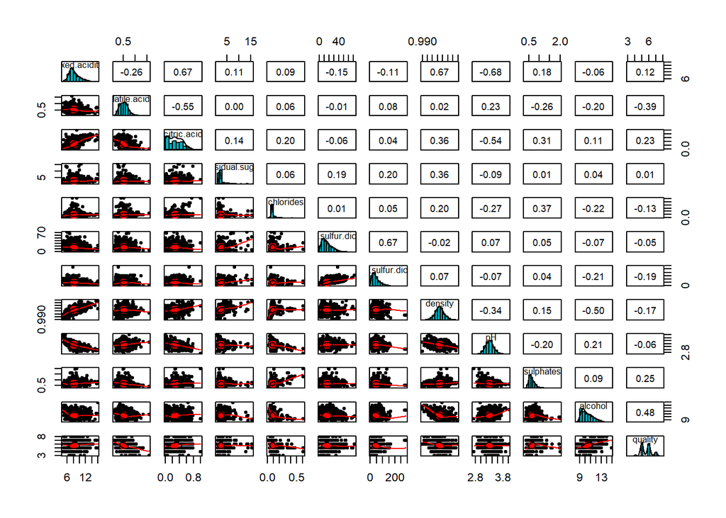

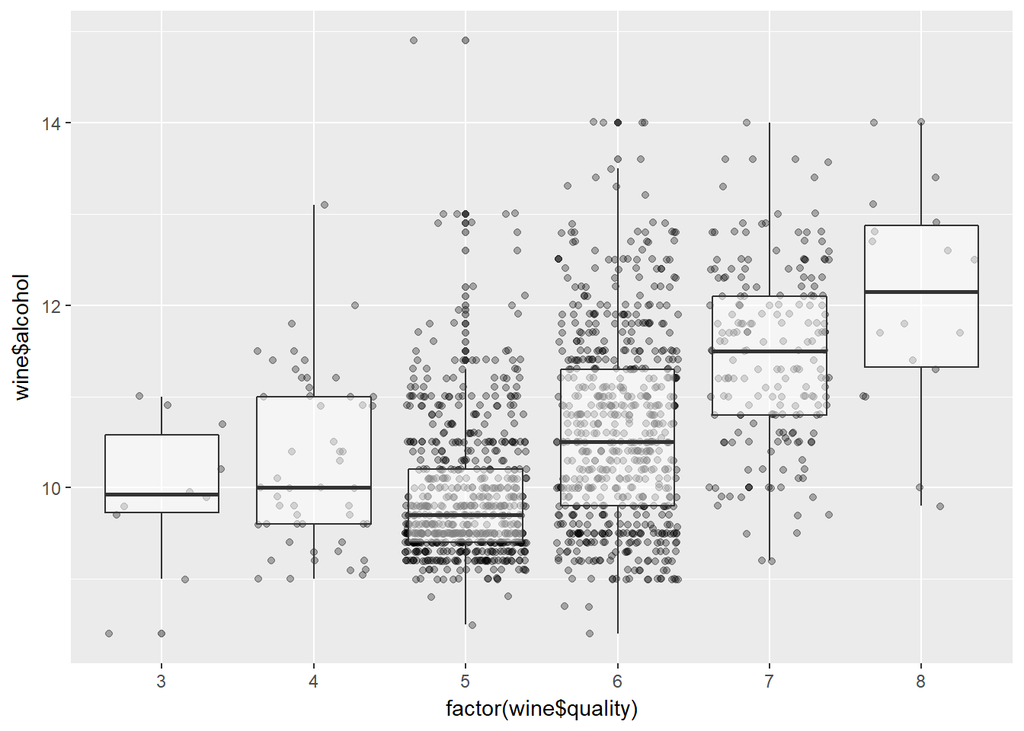

Description: This a combined plot between quality and alcohol. As you can see, wine quality correlates with alcohol. Basically, the higher the alcohol, the better the wine quality.

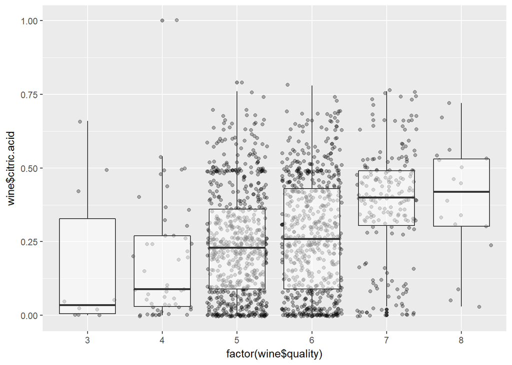

Description: This is another combined plot between quality and citric.acid. I found that citric acid truly contributes to the quality of wine. And I divided these boxes into three groups:

Group 1: quality 3-4 Group 2: quality 5-6 Group 3: quality 7-8

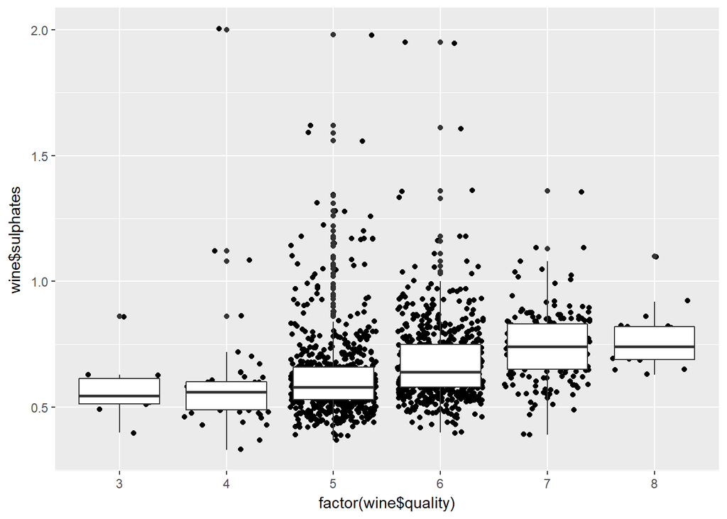

# Bivariate Analysis

### Talk about some of the relationships you observed in this part of the investigation. How did the feature(s) of interest vary with other features in the dataset?

Quality correlates with alcohol, sulphates, citric.acid.

In this section, I mainly explored the relationships between quality and others variables such alcohol, citric.acid.

As the citric.acid varies, Wine quality shows ups and downs wave.

### Did you observe any interesting relationships between the other features (not the main feature(s) of interest)?

The residual sugar of wine is a little bit positively correlated with free sulfur dioxide.

And fixed.acidity correlates positively with citric.acid which makes sense.

### What was the strongest relationship you found?

The quality of a wine is positively and strongly correlated with alcohol(It is relatively strong.) Therefore, it could be used to predict the quality of wines.

# Multivariate Plots Section

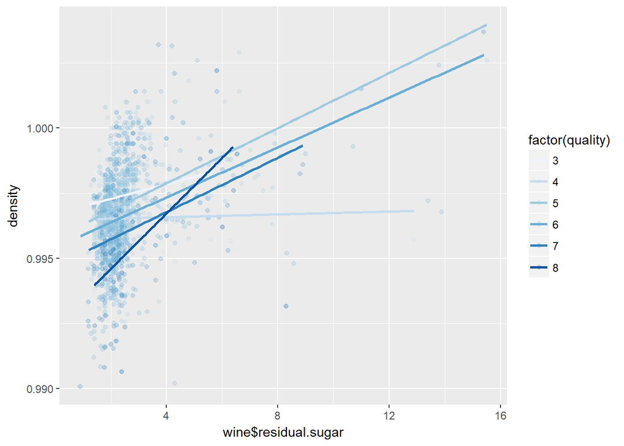

Description: A multi-variable plot which show the relationship among residual sugar,density and quality. I found that the higher the density, the worse the wine quality when keeping residual sugar the same amount. Meanwhile, the amount of residual sugar has no or little impact on wine quality with the same density.

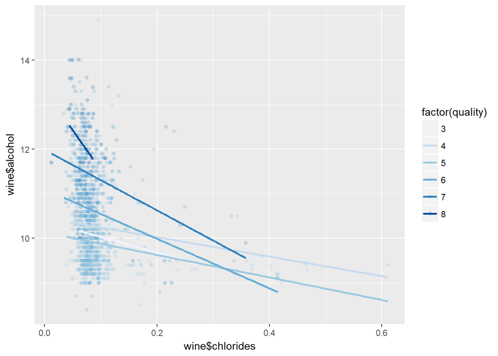

Description: A multi-variable plot which show the relationship among cholorides, alcohol and quality. As the plot shows, The effect of alcohol to quality is greater than the effect of chlorides.

Now, let`s jump into sulphate ~ quality ~ residual sugar

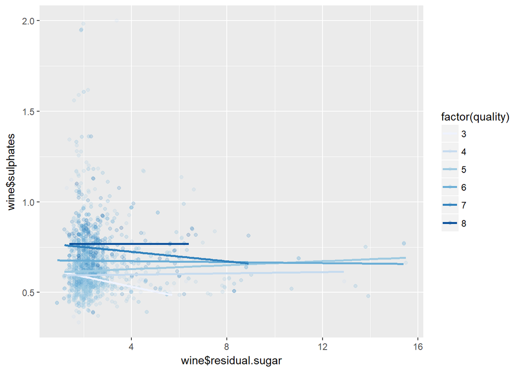

Description: A multi-variable plot which show the relationship among residual sugar, sulphates and quality.

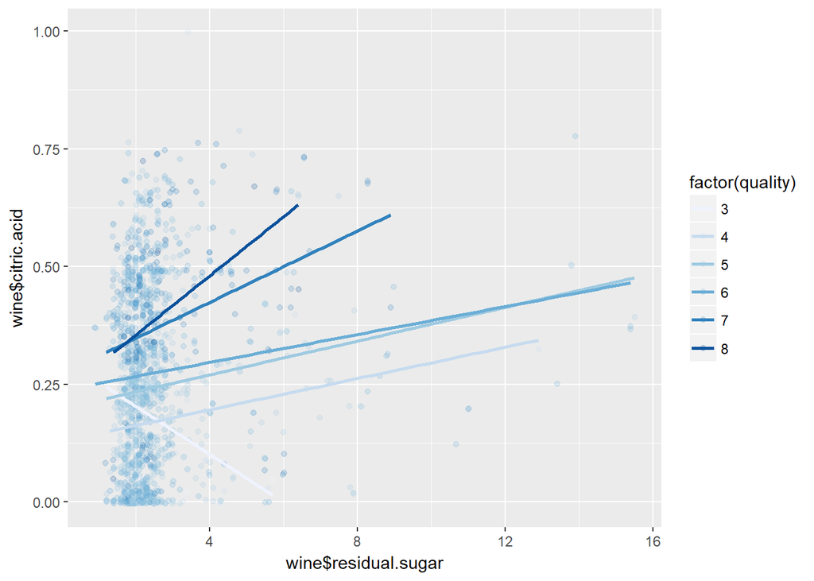

Above all, I converted the quality into factor variable in every plot. Now, I`m gonna to make a different plot in which I would not make any conversion.

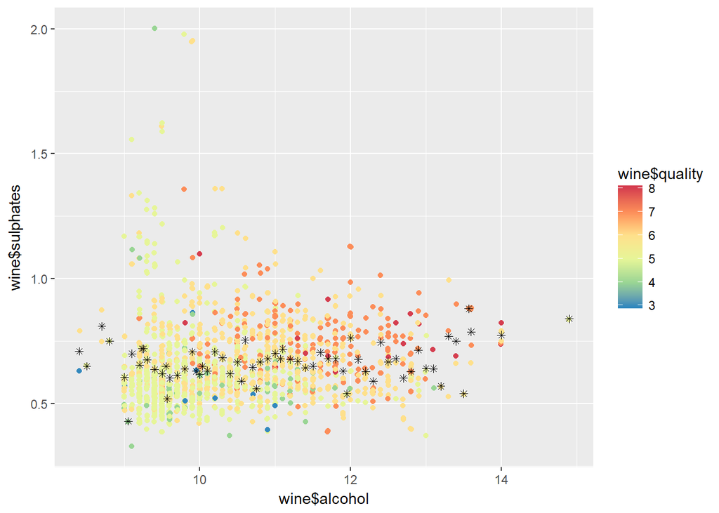

# Multivariate Analysis

### Talk about some of the relationships you observed in this part of the investigation. Were there features that strengthened each other in terms of looking at your feature(s) of interest?

1. When alcohol remains constant, the higher the sulphate, the better the quality of wine. Sulphates and alcohol both contribute to the quality of wine.
2. The effect of alcohol to quality is greater than the effect of chlorides.

### OPTIONAL: Did you create any models with your dataset? Discuss the strengths and limitations of your model.

# Final Plots and Summary

### Plot One

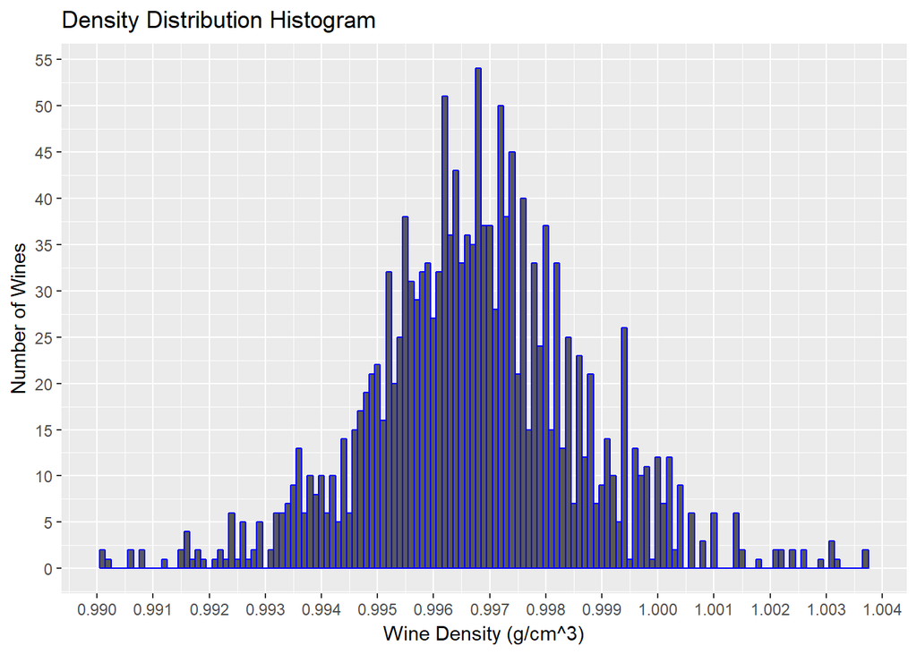

### Description One

The distribution of wine density appears to be normal distribution. And There are also some noticebable gaps in the plot. I guess that is because sample size isn`t large enough.

### Plot Two

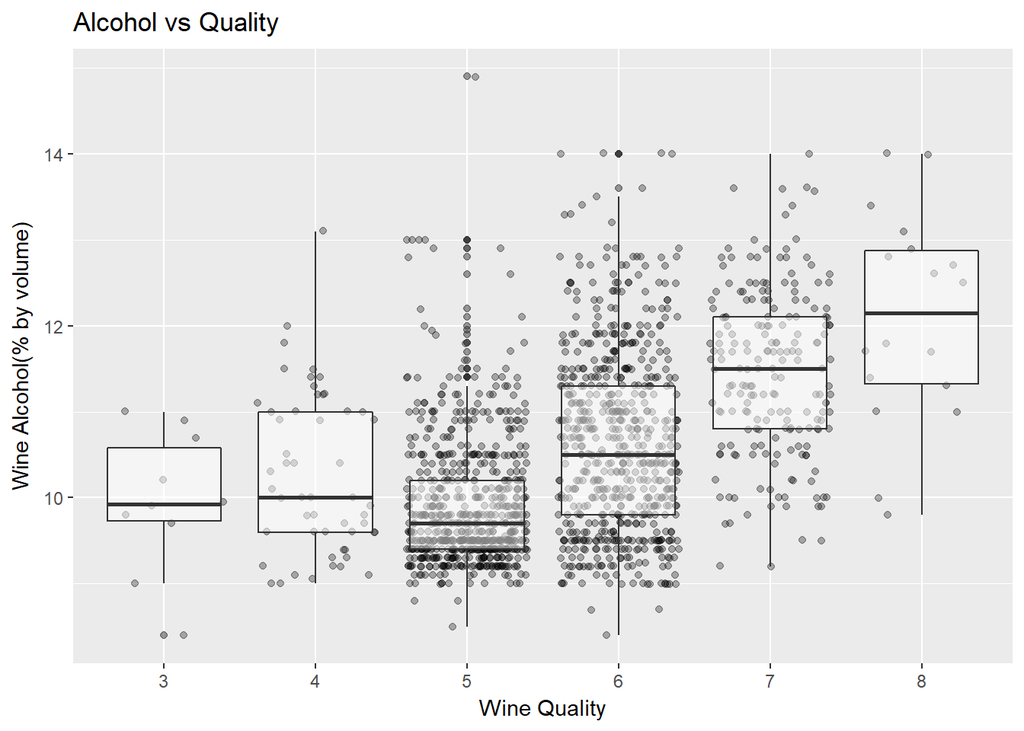

### Description Two

This a combined plot between quality and alcohol. As you can see, wine quality correlates with alcohol. Basically, the higher the alcohol, the better the wine quality.

### Plot Three

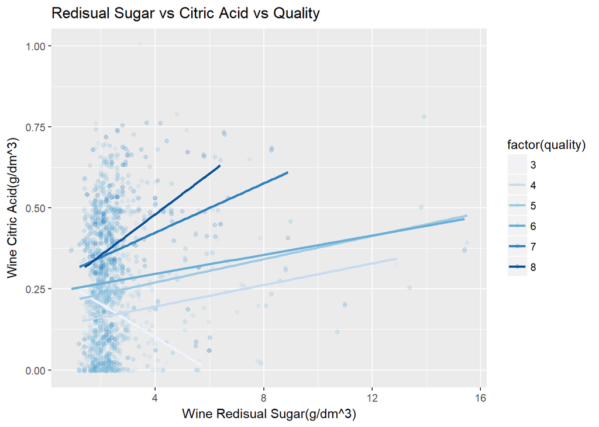

# Reflection

First, I have gradually realized that we shouldn`t set a preconceived condition: I need to make a perfect and full-complete EDA. Instead, we make a jump start by asking several hypothesis or intersting questions after glipmsing dataset. The wine data set contains information on almost 1,599 wines across 12 variables. I started by understanding the single variables such as fixed acidity, chlorides in the data set, and then I explored relationships between variables.

Last, there are some future works need to be done. 1) Maybe I can build a model to predict the quality of wine with variables such alcohol, sulphates or other variables. I finally decide not to do that. One reason is that I find given variables doesn`t correlate with wine quality strongly (the strongest relationship between quality and alcohol is only 0.48) 2) From my personal stand, I think that weather conditions such humidity, temperature can have an important effect on wine quality. So these factors should be added into wine dataset.

This dataset is public available for research. The details are described in [Cortez et al., 2009]. Please include this citation if you plan to use this database:

P. Cortez, A. Cerdeira, F. Almeida, T. Matos and J. Reis. Modeling wine preferences by data mining from physicochemical properties. In Decision Support Systems, Elsevier, 47(4):547-553. ISSN: 0167-9236.

Available at: [@Elsevier] http://dx.doi.org/10.1016/j.dss.2009.05.016 [Pre-press (pdf)] http://www3.dsi.uminho.pt/pcortez/winequality09.pdf [bib] http://www3.dsi.uminho.pt/pcortez/dss09.bib